| REPUBLIQUE DU SENEGAL |
| --- |

[figure not shown]

| ********** |
| --- |
| Un Peuple - Un But - Une Foi |
| ********** |
| Agence nationale de la Statistique et de la démographie |

[figure not shown]

| ********** |
| --- |
| Ecole nationale de la Statistique et de l'Analyse économique Pierre Ndiaye |

[figure not shown]

##### Projet statistique sur R : Evaluation

| Rédigé par | Sous la supervision de |
| --- | --- |
| Samba SOW | M. Aboubacar HEMA |
| Élève Ingénieur Statisticien Économiste | Data-scientist |

| **Année académique 2024-2025** |
| --- |

# Introduction

Ce projet vise à analyser les caractéristiques démographiques et socio-économiques des populations déplacées internes au Soudan en 2023, à travers une approche statistique rigoureuse. En exploitant les données de l’Enquête sur les déplacements forcés, nous étudions notamment la pyramide des âges, la composition des ménages, les conditions de sécurité alimentaire (via le Score de Consommation Alimentaire) et les stratégies de survie (à l’aide de l’indice rCSI). L’analyse combine des méthodes descriptives (tableaux croisés, représentations graphiques) et des tests statistiques pour comparer les réfugiés et les communautés d’accueil, tout en garantissant la qualité des données via un traitement minutieux des valeurs manquantes et incohérentes. Les résultats visent à éclairer les politiques d’aide humanitaire en identifiant les vulnérabilités spécifiques de ces populations.**

**Importation des bases de données**

```r
data_ind <- haven::read_dta("../data/Base_Individus.dta")
data_prin <- haven::read_dta("../data/Base_Principale.dta")
```

```
[1] 3058 1312
```

```
[1] 22092   144
```

L’étude repose sur deux bases de données principales : une base ménages (data_prin) comprenant 3058 observations et 1312 variables, et une base individuelle (data_ind) contenant 22092 individus décrits à travers 144 variables. Ces données proviennent d’une enquête sur les déplacements forcés au Sud-Soudan en 2023. La base principale semble regrouper les informations socioéconomiques et les caractéristiques des ménages, tandis que individu détaille les profils individuels au sein de chaque ménage.

# Analyse de consistence des bases de données

L’analyse de consistance des bases de données consistera à vérifier la cohérence, la qualité et l’intégrité des données avant leur exploitation. Elle inclut la détection des valeurs manquantes, des doublons, des erreurs de saisie, des incohérences logiques et des valeurs aberrantes. Dans cette étape, il sera utilisé des méthodes comme les statistiques descriptives, des vérifications de plages (ex. âge entre 0 et 120 ans) ou des croisements entre variables. Globalement, l’objectif sera de s’assurer que les données reflètent fidèlement la réalité et sont exploitables pour les analyses statistiques ultérieures.

# 1. Nettoyage des noms de colonnes

Le package janitor propose plusieurs fonctions pour nettoyer les noms de colonnes:

```
          nom_avant        nom_apres modifie
1        Intro_07_1       intro_07_1    TRUE
2          Final_01         final_01    TRUE
3                ID               id    TRUE
4      positionofHH    positionof_hh    TRUE
5  Intro_camp_label intro_camp_label    TRUE
6          Intro_02         intro_02    TRUE
7          Intro_08         intro_08    TRUE
8          Intro_09         intro_09    TRUE
9          Intro_15         intro_15    TRUE
10        HH_Lang01        hh_lang01    TRUE
```

Ce script automatise le nettoyage des noms de colonnes (via janitor::clean_names()) et compare les versions avant/après pour identifier les modifications. La fonction clean_names() suit des conventions de nommage cohérentes (minuscules, suppression des caractères spéciaux, remplacement des espaces par des underscores), ce qui facilite l’utilisation ultérieure des variables dans des analyses. Le tableau comparatif changes met en évidence les colonnes renommées, avec un exemple des 10 premières modifications.

**Contrôle des doublons**

*Traitement des doublons*

On utilise ici la fonction get_dupes() du package janitor pour identifier efficacement les doublons dans le jeu de données data_prin, en se basant sur la combinaison des variables ID (identifiant unique) et admin1.

On va identifier les doublons potentiels dans le jeu de données data_prin en regroupant les observations par ID et admin1 (zone administrative), puis en comptant le nombre de lignes identiques (nb_line). Il filtre et trie ensuite les groupes ayant plus d’une occurrence (nb_line > 1), et retourne le nombre total de lignes dupliquées (nrow()).

```
[1] 0
```

```
HH_02 HH_08
   20  7580
```

```
      HH_02       HH_08
 0.09053051 34.31106283
```

Cette visualisation présente la distribution par âge et sexe de la population sous forme de pyramide, après un nettoyage des données (suppression des NA) et un découpage en tranches d’âge de 5 ans. Les hommes (en vert) sont représentés à gauche (valeurs négatives) et les femmes (en rose) à droite, permettant une comparaison immédiate des structures démographiques.

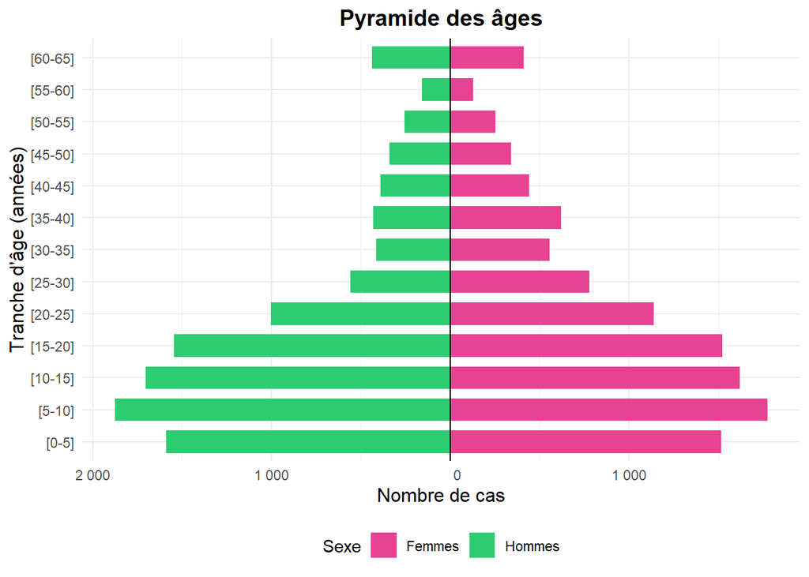

##2) Caracteristiques du chef de menage

[output not shown]

<sup>1</sup> Mean(Minimum,Maximum); %  
<sup>2</sup> Wilcoxon rank sum test; Pearson’s Chi-squared test

# 3) Crowding Index ou l’indice d’affluence

L’indice d’affluence est le nombre de membres du menage divise par le nombre de pièces (à l’exclusion de la cuisine et des couloirs).

2. Statistiques descriptives sur cette variable

```
   Min. 1st Qu.  Median    Mean 3rd Qu.    Max.
  1.000   5.000   7.000   7.128   9.000  17.000
```

Cette visualisation permet d’identifier rapidement les tailles de ménage les plus courantes, la dispersion globale, et d’éventuelles particularités dans la distribution (comme des valeurs extrêmes ou des modes multiples).

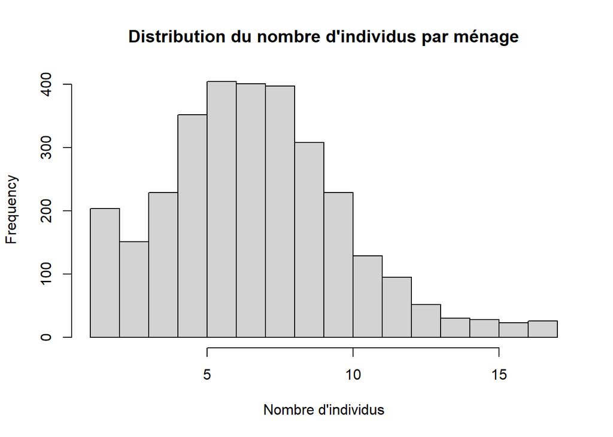

3. Statistiques descriptives sur le nombre de pièces

```
   Min. 1st Qu.  Median    Mean 3rd Qu.    Max.    NA's
  1.000   2.000   2.000   2.388   3.000  21.000       6
```

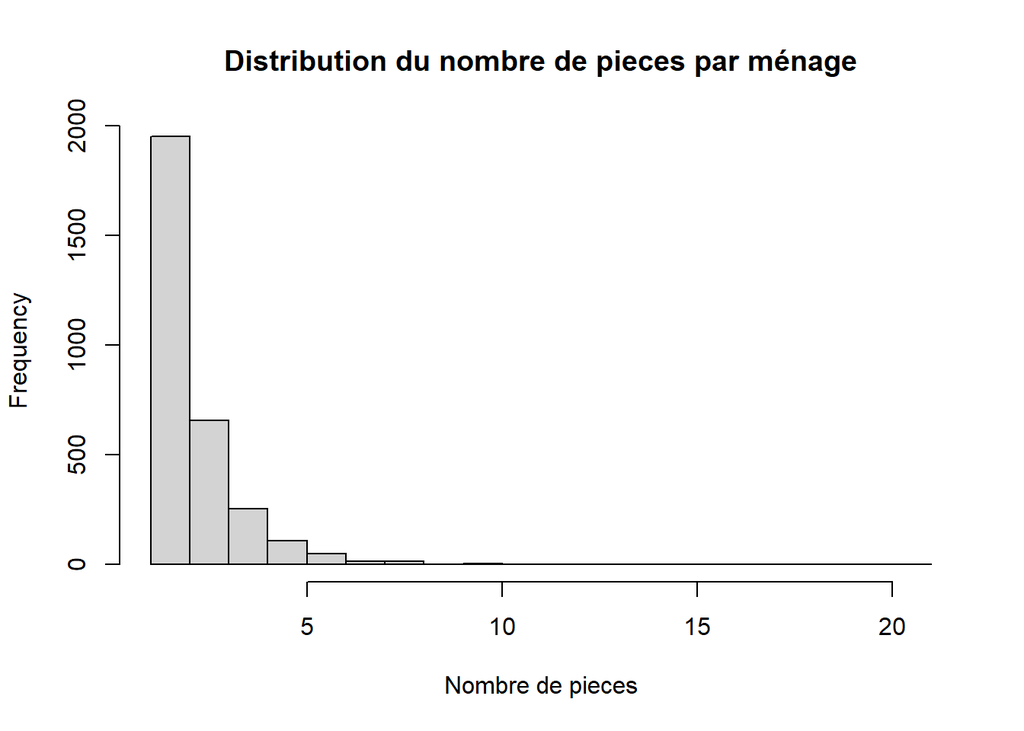

4. Calculer le Crowding Index

```
   Min. 1st Qu.  Median    Mean 3rd Qu.    Max.
 0.1429  2.0000  3.0000  3.5548  4.5000 15.0000
```

5. Catégoriser l’indice d’affluence et calculer les proportions

Nous allons catégoriser l’indice d’affluence en quatre groupes : inférieur à 1, entre 1 et 2, entre 2 et 3, et supérieur ou égal à 3.

```
       <1       >=3    1 - <2    2 - <3
 2.228047 58.027523 15.596330 24.148100
```

6. Proportions selon le statut : réfugié vs hôte

Ici on analyse la répartition des ménages selon leur niveau de surpeuplement (crowding_cat) pour chaque type de ménage (HH08), en calculant à la fois les effectifs absolus (n) et les proportions relatives (prop) au sein de chaque catégorie HH08. Les proportions sont standardisées (en pourcentage arrondi à 0,1) pour permettre des comparaisons entre les différents types de ménage, tout en conservant l’information sur les effectifs bruts. Le résultat final, trié par type de ménage puis par catégorie de surpeuplement, permet d’identifier d’éventuelles disparités dans les conditions de logement selon les caractéristiques des ménages, offrant ainsi une vision claire des inégalités résidentielles entre les différents groupes.

| HH08 | crowding_cat | n | prop |
| --- | --- | --- | --- |
| 1 | 1 - <2 | 28 | 11.8 |
| 1 | 2 - <3 | 46 | 19.3 |
| 1 | <1 | 5 | 2.1 |
| 1 | >=3 | 159 | 66.8 |
| 2 | 1 - <2 | 94 | 11.5 |
| 2 | 2 - <3 | 216 | 26.5 |
| 2 | <1 | 15 | 1.8 |
| 2 | >=3 | 490 | 60.1 |
| 3 | 1 - <2 | 4 | 12.5 |
| 3 | 2 - <3 | 7 | 21.9 |

[output cut: 6 more lines]

# III. Analyse de la securite alimentaire des deplaces internes

*5) L’indice réduit des stratégies de survie (rCSI)*

L’indice réduit des stratégies de survie, basé sur la consommation, est utilisé pour évaluer le niveau de stress d’un ménage dû à une pénurie alimentaire. Il mesure les stratégies comportementales que les gens appliquent lorsqu’ils n’ont pas accès à suffisamment de nourriture ou lorsqu’ils prévoient une diminution de la sécurité alimentaire.

1. Faites une analyse descriptive des variables qui composent le rCSI

Ce tableau résume les cinq variables alimentaires (Food02a à Food08a) utilisées pour calculer l’indice rCSI, présentant pour chacune les effectifs (n) et pourcentages correspondants, tout en indiquant les valeurs manquantes le cas échéant. La mise en gras des libellés améliore la lisibilité de ce panorama initial qui permet de vérifier la distribution des composantes du score avant agrégation, d’identifier d’éventuelles anomalies dans les données, et d’évaluer leur contribution relative à la mesure globale de l’insécurité alimentaire.

| **Characteristic** | **N = 3,052**<sup>1</sup> |
| --- | --- |
| A member ate less preferred food and less expensive food [Past 30/7 days] |  |
| 1 | 2,488 (82%) |
| 2 | 563 (18%) |
| Unknown | 1 |
| Any member borrowed food/relied on help to get more food...[Past 30/7 days] |  |
| 1 | 1,827 (60%) |
| 2 | 1,220 (40%) |
| Unknown | 5 |
| Any member ate a smaller meal than you felt you needed [Past 30/7 days] |  |
| 1 | 2,594 (85%) |
| 2 | 454 (15%) |
| Unknown | 4 |
| Adults ate less to have more food for children under 5? [Past 30/7 days] |  |
| 1 | 2,140 (70%) |
| 2 | 906 (30%) |
| Unknown | 6 |
| Any member ate fewer meals in a day [Past 30/7 days] |  |
| 1 | 2,541 (83%) |
| 2 | 510 (17%) |
| Unknown | 1 |

<sup>1</sup> n (%)

On s’interesse maintenant aux valeurs numeriques comprisent entre 0 et 7. Pour chacune des variables qui composent le rCSI, creez des nouvelles variables pour chacune des variables du rCSI selon les conditions suivantes: Si la modalite de la variable est yes generez aleatoirement une valeur comprise entre 1 et 7 attribue a la variable, dans le cas contraire la nouvelle variable prend 0.

## b) Statistiques descriptives sur les nouvelles variables numériques

Ce tableau présente la répartition sur 7 jours de différentes habitudes alimentaires (freq_food02a à freq_food08a) pour 3 052 individus. Les chiffres indiquent le pourcentage de personnes consommant un aliment donné pendant 0 à 7 jours par semaine. Par exemple, freq_food05a montre que 40% des individus ne consomment jamais cet aliment (0 jour), tandis que seulement 8,5% le consomment 1 jour ou 5 jours par semaine, suggérant une consommation occasionnelle ou rare. À l’inverse, freq_food08a affiche une répartition plus uniforme (11–12% par jour), indiquant une consommation régulière tout au long de la semaine. Ces résultats pourraient refléter des différences culturelles, des restrictions alimentaires ou des préférences individuelles, mais une analyse plus poussée serait nécessaire pour identifier les facteurs explicatifs.

| **Characteristic** | **N = 3,052**<sup>1</sup> |
| --- | --- |
| freq_food02a |  |
| 0 | 563 (18%) |
| 1 | 360 (12%) |
| 2 | 350 (11%) |
| 3 | 365 (12%) |
| 4 | 336 (11%) |
| 5 | 350 (11%) |
| 6 | 349 (11%) |
| 7 | 378 (12%) |
| freq_food05a |  |
| 0 | 1,220 (40%) |
| 1 | 259 (8.5%) |
| 2 | 306 (10%) |
| 3 | 243 (8.0%) |
| 4 | 258 (8.5%) |
| 5 | 260 (8.5%) |
| 6 | 258 (8.5%) |
| 7 | 243 (8.0%) |
| freq_food06a |  |
| 0 | 454 (15%) |
| 1 | 350 (11%) |
| 2 | 345 (11%) |
| 3 | 377 (12%) |
| 4 | 395 (13%) |
| 5 | 362 (12%) |
| 6 | 351 (12%) |
| 7 | 414 (14%) |
| freq_food07a |  |
| 0 | 906 (30%) |
| 1 | 328 (11%) |
| 2 | 303 (9.9%) |
| 3 | 319 (10%) |
| 4 | 249 (8.2%) |
| 5 | 339 (11%) |
| 6 | 324 (11%) |
| 7 | 278 (9.1%) |
| freq_food08a |  |
| 0 | 510 (17%) |
| 1 | 374 (12%) |
| 2 | 377 (12%) |
| 3 | 352 (12%) |
| 4 | 335 (11%) |
| 5 | 352 (12%) |
| 6 | 371 (12%) |
| 7 | 380 (12%) |

<sup>1</sup> n (%)

3. Cacul de l indice

Pour évaluer l’insécurité alimentaire des ménages, nous calculons ici l’indice rCSI (reduced Coping Strategies Index), un indicateur agrégé reflétant les stratégies d’adaptation face au manque de nourriture. Cet indice est obtenu en pondérant les fréquences hebdomadaires de différentes pratiques alimentaires (freq_food02a à freq_food08a), selon leur gravité perçue.

Vérifions satistiquement les valeurs du score

```
   Min. 1st Qu.  Median    Mean 3rd Qu.    Max.    NA's
   0.00   18.00   27.00   25.35   34.00   52.00      14
```

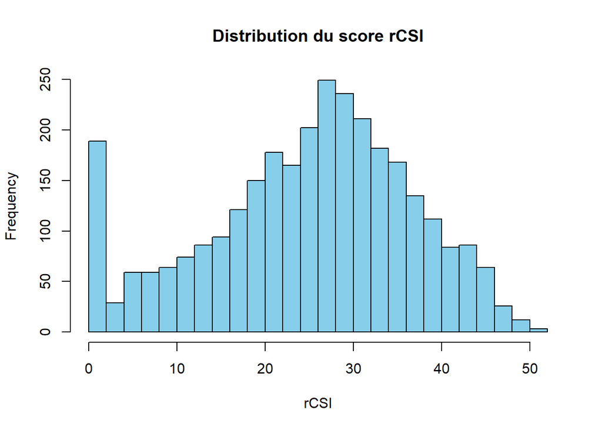

## e) Faites une representation spatiale selon le milieu de residence du rCSI

[figure not shown]